# PCIT-CoS-Waitlist RCT Paper 1: DECA Initiative ASD

Nancy Briggs

05 JAN 2021

### DECA Initiative Adjusting for ASD

#### Descriptives

| asdcase | group | time | n | mean | sd | median | min | max |
| --- | --- | --- | --- | --- | --- | --- | --- | --- |
| 0 | 1 | 1 | 24 | 44.75000 | 9.037362 | 46.0 | 28 | 63 |
| 0 | 1 | 2 | 19 | 47.42105 | 10.584663 | 47.0 | 31 | 64 |
| 0 | 1 | 3 | 14 | 47.85714 | 6.347103 | 47.0 | 39 | 57 |
| 0 | 2 | 1 | 24 | 46.16667 | 9.902423 | 44.5 | 32 | 63 |
| 0 | 2 | 2 | 11 | 45.54545 | 12.135597 | 44.0 | 28 | 70 |
| 0 | 2 | 3 | 5 | 46.60000 | 8.443933 | 50.0 | 33 | 53 |
| 0 | 3 | 1 | 25 | 49.24000 | 10.329085 | 50.0 | 31 | 72 |
| 0 | 3 | 2 | 22 | 43.54545 | 11.219572 | 43.0 | 28 | 70 |
| 0 | 3 | 3 | 0 | NaN | NA | NA | Inf | -Inf |
| 1 | 1 | 1 | 6 | 38.00000 | 7.745967 | 38.0 | 28 | 48 |
| 1 | 1 | 2 | 5 | 38.00000 | 10.222524 | 33.0 | 28 | 50 |
| 1 | 1 | 3 | 5 | 32.20000 | 5.019960 | 30.0 | 28 | 39 |
| 1 | 2 | 1 | 3 | 32.00000 | 4.582576 | 31.0 | 28 | 37 |
| 1 | 2 | 2 | 2 | 40.00000 | 11.313709 | 40.0 | 32 | 48 |
| 1 | 2 | 3 | 0 | NaN | NA | NA | Inf | -Inf |
| 1 | 3 | 1 | 5 | 34.40000 | 7.092249 | 32.0 | 30 | 47 |
| 1 | 3 | 2 | 4 | 31.50000 | 2.886751 | 31.5 | 28 | 35 |
| 1 | 3 | 3 | 0 | NaN | NA | NA | Inf | -Inf |

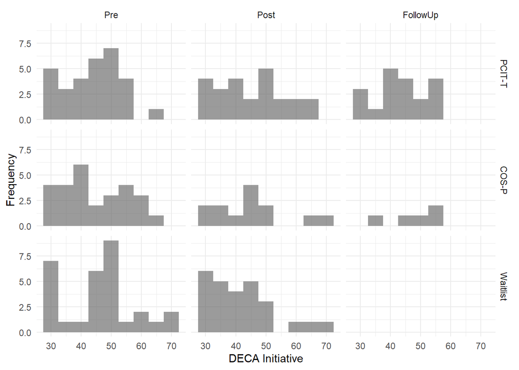

#### Model & Results

A linear mixed model with random effect for individual and fixed effects of group, time and the interaction was run. ASD status was then entered into the model as a main effect and then the 3-way interaction. Estimated marginal means were obtained, and contrasts specified to test Hypothesis 1 and Hypothesis 2.

```
## fixed-effect model matrix is rank deficient so dropping 1 column / coefficient
```

```
## fixed-effect model matrix is rank deficient so dropping 3 columns / coefficients
```

This is the ANOVA table for the model. p-values are likelihood ratio tests for adding the new term to the model just before. A p-value <0.05 indicates that adding that term results in better model fit. The most important p-value is the interaction p-value.

```
## refitting model(s) with ML (instead of REML)
```

[output not shown]

There is no evidence that ASD moderates the 2-way group*time interaction the 3-way interaction (p=0.544).

Model3, the model with Group*Time, adjusted by ASD will be the model I use for Estimated Means.

```r
summary(result3)
```

```
## Linear mixed model fit by REML. t-tests use Satterthwaite's method [
## lmerModLmerTest]
## Formula: outcome ~ asdcase + group * time + (1 | id)
##    Data: dat
##
## REML criterion at convergence: 1221.5
##
## Scaled residuals:
##      Min       1Q   Median       3Q      Max
## -1.75267 -0.63205 -0.07981  0.53720  2.23166
##
## Random effects:
##  Groups   Name        Variance Std.Dev.
##  id       (Intercept) 44.98    6.706
##  Residual             49.35    7.025
## Number of obs: 174, groups:  id, 88
##
## Fixed effects:
##                Estimate Std. Error         df t value Pr(>|t|)
## (Intercept)   45.654395   1.840493 123.039944  24.806  < 2e-16 ***
## asdcase1     -11.271976   2.465976  73.583397  -4.571 1.92e-05 ***
## group2        -0.006331   2.580863 128.457967  -0.002   0.9980
## group3         2.990934   2.509005 127.370442   1.192   0.2354
## time2          1.602831   1.974162  86.268031   0.812   0.4191
## time3         -0.402459   2.148591  88.849313  -0.187   0.8518
## group2:time2  -1.097661   3.265135  99.378877  -0.336   0.7374
## group3:time2  -6.313867   2.749828  85.007962  -2.296   0.0241 *
## group2:time3   2.452586   4.389242 100.022207   0.559   0.5776
## ---
## Signif. codes:  0 '***' 0.001 '**' 0.01 '*' 0.05 '.' 0.1 ' ' 1
##
## Correlation of Fixed Effects:
##             (Intr) asdcs1 group2 group3 time2  time3  grp2:2 grp3:2
## asdcase1    -0.268
## group2      -0.685  0.087
## group3      -0.690  0.033  0.488
## time2       -0.451 -0.005  0.322  0.332
## time3       -0.409 -0.027  0.294  0.304  0.434
## group2:tim2  0.277 -0.013 -0.423 -0.201 -0.605 -0.262
## group3:tim2  0.322  0.010 -0.231 -0.477 -0.718 -0.312  0.434
## group2:tim3  0.195  0.031 -0.305 -0.148 -0.213 -0.490  0.328  0.153
## fit warnings:
## fixed-effect model matrix is rank deficient so dropping 1 column / coefficient
```

#### Estimated Means & Change

Estimated means for each Treatment and Time (adjusted by ASD status) are presented. In addition, within-group change between time points is presented with 95% CIs.

##### Group mean difference at each timepoint

Effect sizes all calculated by the pooled T1 SD of the outcome. Adjusted p-value from Bonferroni correction.

Group Differences at Each Time Point

| Group Difference | Time | Mean | SE | t | p | adj p | Lower CL | Upper CL | Effect Size | Lower CL | Upper CL |
| --- | --- | --- | --- | --- | --- | --- | --- | --- | --- | --- | --- |
| 1 - 2 | 1 | 0.006 | 2.581 | 0.002 | 1.000 | 1.000 | -6.113 | 6.125 | 0.001 | -0.599 | 0.441 |
| 1 - 3 | 1 | -2.991 | 2.509 | -1.192 | 0.460 | 0.706 | -8.939 | 2.957 | -0.307 | -0.802 | 0.174 |
| 2 - 3 | 1 | -2.997 | 2.575 | -1.164 | 0.477 | 0.740 | -9.102 | 3.108 | -0.307 | -0.717 | 0.252 |
| 1 - 2 | 2 | 1.104 | 3.203 | 0.345 | 0.937 | 1.000 | -6.473 | 8.681 | 0.113 | -0.561 | 0.681 |
| 1 - 3 | 2 | 3.323 | 2.702 | 1.230 | 0.438 | 0.662 | -3.076 | 9.722 | 0.341 | -0.270 | 0.804 |
| 2 - 3 | 2 | 2.219 | 3.161 | 0.702 | 0.763 | 1.000 | -5.259 | 9.697 | 0.228 | -0.380 | 0.938 |
| 1 - 2 | 3 | -2.446 | 4.381 | -0.558 | 0.842 | 1.000 | -12.813 | 7.921 | -0.251 | -1.337 | 0.464 |
| 1 - 3 | 3 | NA | NA | NA | NA | NA | NA | NA | NA | NA | NA |
| 2 - 3 | 3 | NA | NA | NA | NA | NA | NA | NA | NA | NA | NA |

* Effect size scaled by pooled T1 SD  
† ES 95% Bootstrapped Percentile CI limits  
‡ If you want a positive ES (and it is calculated as negative), be sure to switch the signs and positions of the lower and upper CIs.

##### Change within each group

Within-Group Change and Effect Sizes

| Change | Group | Mean | SE | t | p | adj p | Lower CL | Upper CL | Effect Size | Lower CL | Upper CL |
| --- | --- | --- | --- | --- | --- | --- | --- | --- | --- | --- | --- |
| 1 - 2 | 1 | -1.603 | 1.977 | -0.811 | 0.697 | 1.000 | -6.314 | 3.109 | -0.164 | -0.512 | 0.249 |
| 1 - 3 | 1 | 0.402 | 2.154 | 0.187 | 0.981 | 1.000 | -4.727 | 5.532 | 0.041 | -0.300 | 0.509 |
| 2 - 3 | 1 | 2.005 | 2.200 | 0.912 | 0.635 | 1.000 | -3.241 | 7.252 | 0.206 | -0.177 | 0.649 |
| 1 - 2 | 2 | -0.505 | 2.614 | -0.193 | 0.980 | 1.000 | -6.715 | 5.704 | -0.052 | -0.522 | 0.481 |
| 1 - 3 | 2 | -2.050 | 3.848 | -0.533 | 0.855 | 1.000 | -11.195 | 7.095 | -0.210 | -1.094 | 0.540 |
| 2 - 3 | 2 | -1.545 | 3.975 | -0.389 | 0.920 | 1.000 | -11.008 | 7.918 | -0.158 | -1.029 | 0.551 |
| 1 - 2 | 3 | 4.711 | 1.916 | 2.459 | 0.042 | 0.048 | 0.143 | 9.279 | 0.483 | 0.108 | 0.861 |
| 1 - 3 | 3 | NA | NA | NA | NA | NA | NA | NA | NA | NA | NA |
| 2 - 3 | 3 | NA | NA | NA | NA | NA | NA | NA | NA | NA | NA |

* Effect size scaled by pooled T1 SD  
† ES 95% Bootstrapped Percentile CI limits  
‡ If you want a positive ES (and it is calculated as negative), be sure to switch the signs and positions of the lower and upper CIs.

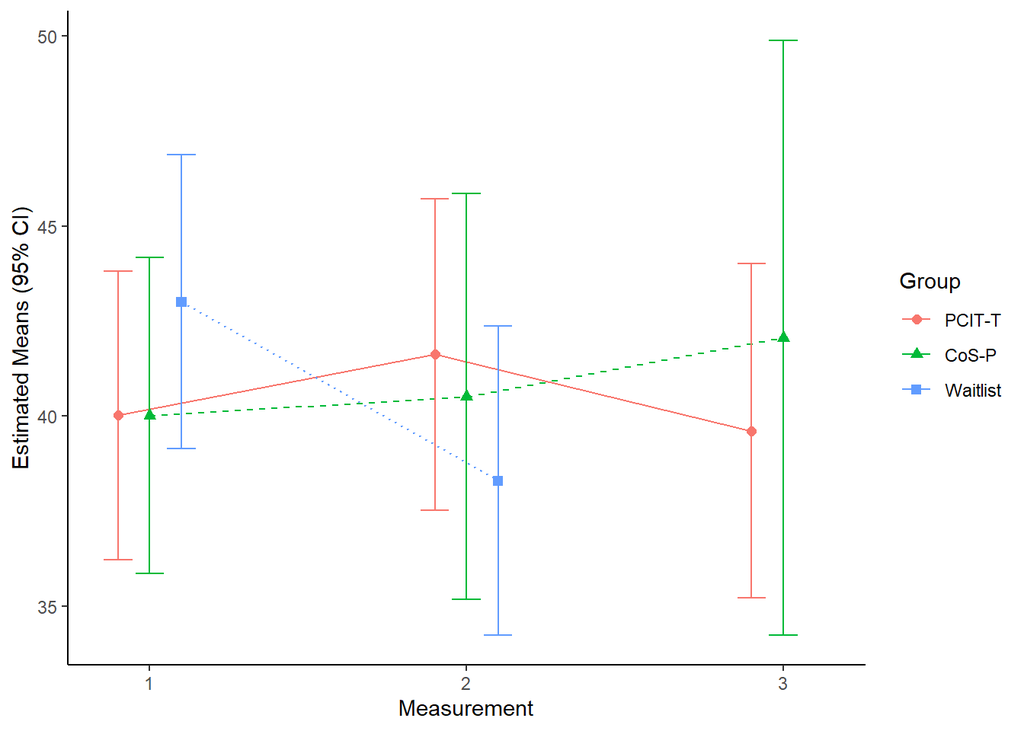

#### Hypothesis 1

We hypothesize that from baseline (‘T1’) to post-treatment/waitlist (‘T2’) there will be a gradient effect, whereby parent-child dyads who receive PCIT-T will show the greatest gains and parent-child dyads who receive no treatment will show the least gains. For the outcome, then, the null hypothesis is:

$H_0: \text {mean change}(\text{PCIT-T}) = \text {mean change}(\text{CoS-P}) = \text {mean change}(\text{Waitlist})$ $H_A: \text {mean change}(\text{PCIT-T}) > \text {mean change}(\text{CoS-P}) > \text {mean change}(\text{Waitlist})$

This is a joint hypothesis test.

First, confirming that the ordering of the means is as hypothesized:

```
## group = 1:
##  contrast estimate   SE    df t.ratio p.value
##  1 - 2      -1.603 1.98  90.3  -0.811  0.6974
##  1 - 3       0.402 2.15  92.9   0.187  0.9809
##  2 - 3       2.005 2.20  86.5   0.912  0.6345
##
## group = 2:
##  contrast estimate   SE    df t.ratio p.value
##  1 - 2      -0.505 2.61 111.2  -0.193  0.9796
##  1 - 3      -2.050 3.85 107.7  -0.533  0.8554
##  2 - 3      -1.545 3.98  96.2  -0.389  0.9202
##
## group = 3:
##  contrast estimate   SE    df t.ratio p.value
##  1 - 2       4.711 1.92  87.8   2.459  0.0417
##  1 - 3      nonEst   NA    NA      NA      NA
##  2 - 3      nonEst   NA    NA      NA      NA
##
## Results are averaged over the levels of: asdcase
## Degrees-of-freedom method: kenward-roger
## P value adjustment: tukey method for comparing a family of 3 estimates
```

The increase is larger in PCITT than in COSP.

```
##   (Intercept) asdcase1 group2 group3 time2 time3 group2:time2 group3:time2
## 1           0        0      0      0     0     0            1            0
## 2           0        0      0      0     0     0           -1            1
##   group2:time3
## 1            0
## 2            0
```

```
##
##   General Linear Hypotheses
##
## Linear Hypotheses:
##        Estimate
## 1 == 0   -1.098
## 2 == 0   -5.216
##
## Global Test:
##       F DF1 DF2  Pr(>F)
## 1 2.904   2 163 0.05762
```

p>0.05, so this joint hypothesis is not supported.

#### Hypothesis 2

There will be a gradient of size of change from T2 to T3 such that the change in the PCIT-T group > the change in the CoS-P group. This isn’t really a gradient; it’s just 1 hypothesis.

First, the change in PCITT and COSP from time 2 to time 3:

```
## group = 1:
##  contrast estimate   SE    df t.ratio p.value
##  1 - 2      -1.603 1.98  90.3  -0.811  0.6974
##  1 - 3       0.402 2.15  92.9   0.187  0.9809
##  2 - 3       2.005 2.20  86.5   0.912  0.6345
##
## group = 2:
##  contrast estimate   SE    df t.ratio p.value
##  1 - 2      -0.505 2.61 111.2  -0.193  0.9796
##  1 - 3      -2.050 3.85 107.7  -0.533  0.8554
##  2 - 3      -1.545 3.98  96.2  -0.389  0.9202
##
## group = 3:
##  contrast estimate   SE    df t.ratio p.value
##  1 - 2       4.711 1.92  87.8   2.459  0.0417
##  1 - 3      nonEst   NA    NA      NA      NA
##  2 - 3      nonEst   NA    NA      NA      NA
##
## Results are averaged over the levels of: asdcase
## Degrees-of-freedom method: kenward-roger
## P value adjustment: tukey method for comparing a family of 3 estimates
```

```
##
##   Simultaneous Tests for General Linear Hypotheses
##
## Fit: lmer(formula = outcome ~ asdcase + group * time + (1 | id), data = dat)
##
## Linear Hypotheses:
##        Estimate Std. Error z value Pr(>|z|)
## 1 == 0    3.550      4.531   0.783    0.433
## (Adjusted p values reported -- single-step method)
```

p>0.05, so we do not have enough evidence to suggest that the change from t2 to t3 in PCITT is greater than the change in COSP, adjusting for ASD diagnosis.

#### Residuals

Assumptions of the model are met.

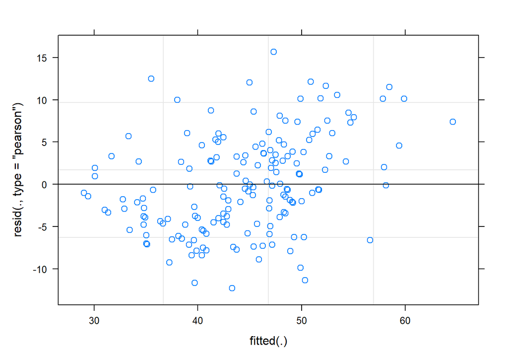

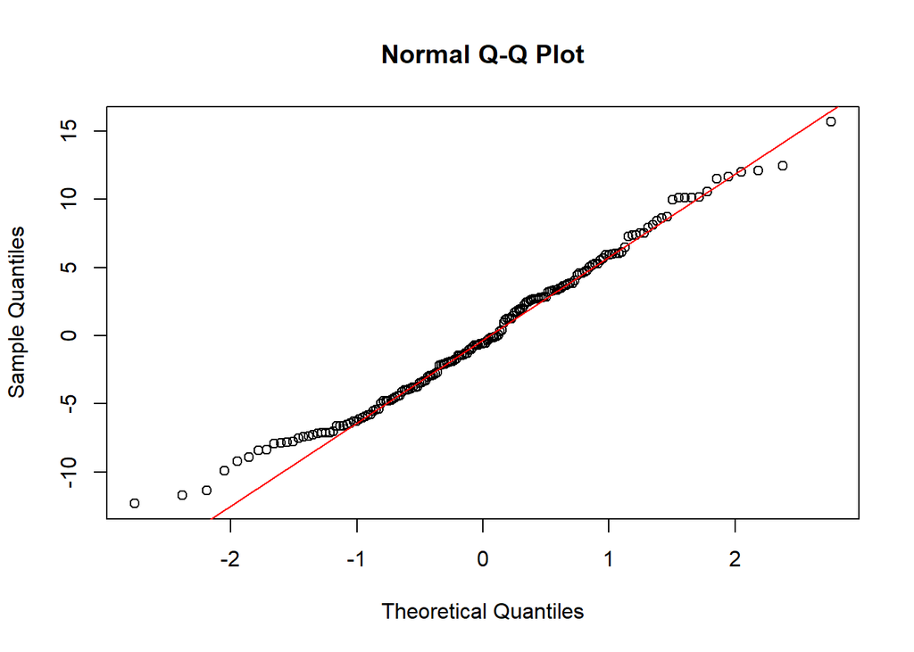

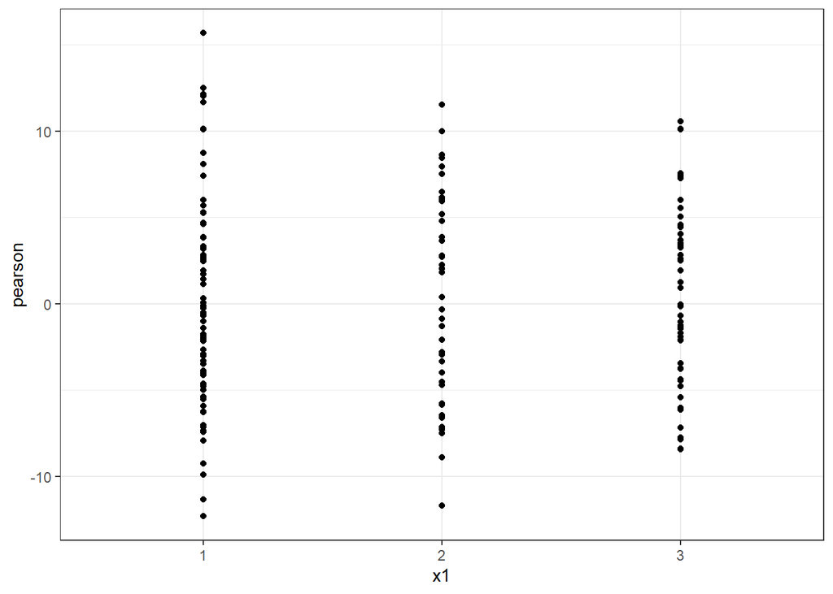

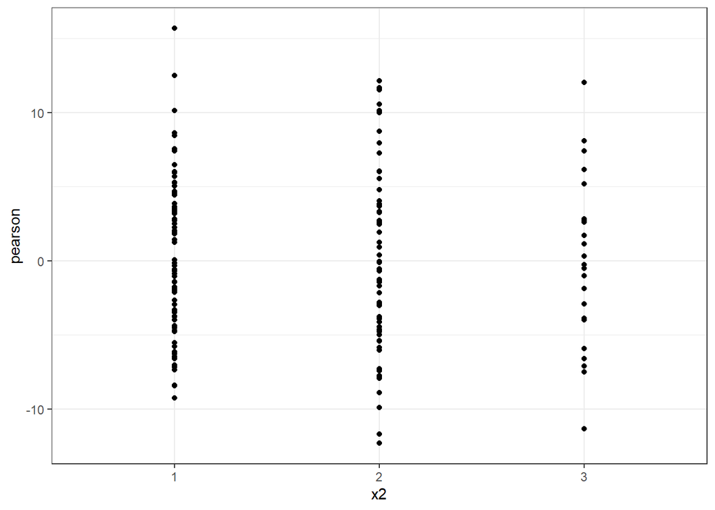

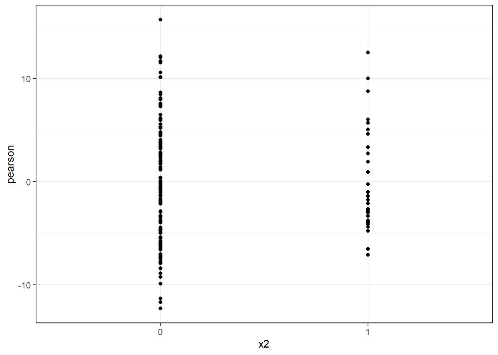

```r
rm(list = ls())
```